# Data Exploration & Deterministic Functions

Ednita Tavarez-Jimenez

## Q1: Terrain Histograms

Create histograms for the three terrain variables: elevation, slope, and aspect. Plot all three histograms in one figure and include it in your report.

```r
require(here)
here()
```

```
## [1] "/Users/ednitatavarez/Environmental Data/Environmental_Data"
```

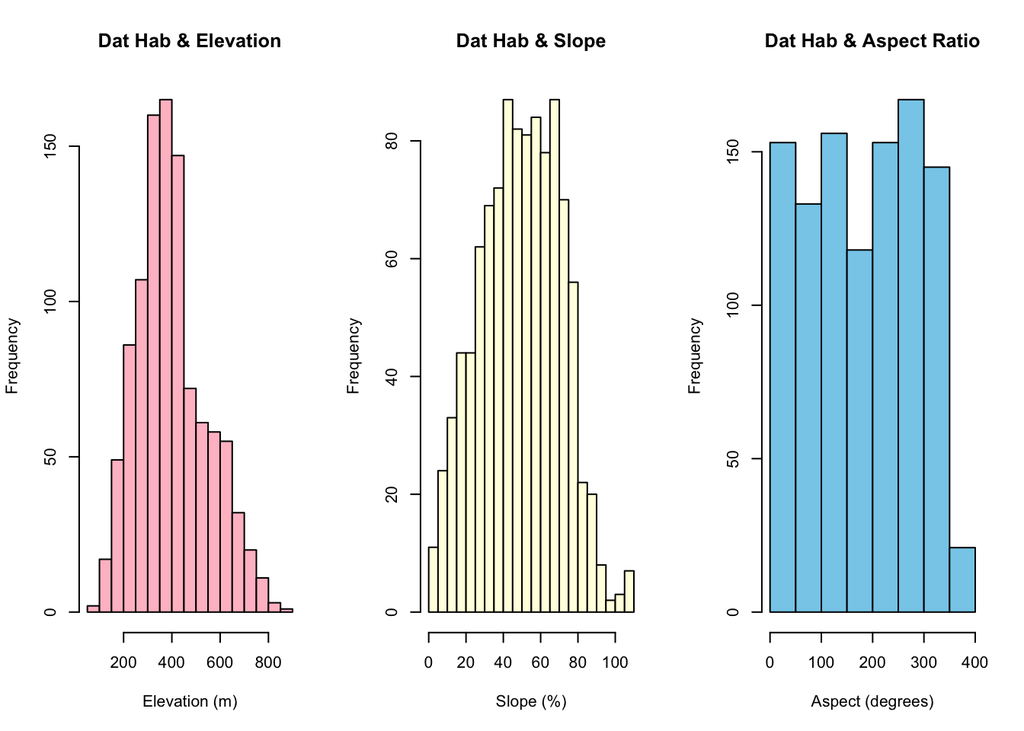

```r
dat_hab <- read.csv(here("data/hab.sta.csv"))

par(mfrow = c(1, 3))
hist(dat_hab$elev,col = "pink", main = "Dat Hab & Elevation", xlab = "Elevation (m)", breaks = 25)
hist(dat_hab$slope, col = "light yellow", main = "Dat Hab & Slope", xlab = "Slope (%)", breaks = 25)
hist(dat_hab$aspect, col = "sky blue",border = "black", main = "Dat Hab & Aspect Ratio", xlab = "Aspect (degrees)", breaks = 10)
```

## Q3: Slope Units

What are the units of slope in this data set?

elevation (m), percent slope (%), aspect (degrees)

## Q4: Slope Histogram Interpretation

Consider the distribution of slopes at the bird census sample sites.

## Q5: Aspects

Briefly define aspect, describing the units used in this dataset

Aspect is the proportional relationship between width and height of the data’s plot axis. The units used in this database is degrees.

## Q7: Terrain/Basal Area Linear Models

Create scatterplots of total basal area and each of the the terrain variables: elevation, slope, and aspect. Basal area should be on the y-axis. Visually inspect the plots and fit a linear function to each terrain variable. Review the linear model parameterization section of the assignment walkthrough if needed.

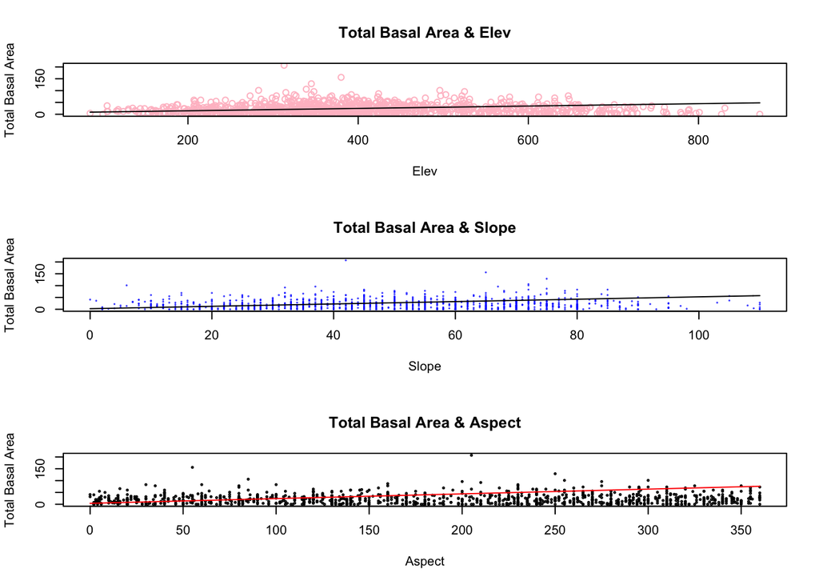

## Q8: Terrain/Basal Model Interpretation

For each terrain variable (elevation, slope, aspect), describe the relationship you observe and your model fit. You should consider

**Is there a noticeable association? The noticeable association I see is that they all have x1 & y1 = 5. Otherwise I don’t really see an association between them.**

If so, is it linear? Based on a visual assessment, is your linear model a good fit for the data, why or why not?

**I don’t think that the the linear model is a good fit because there are so many data points and its makes it hard to see.**